# Project Outline 📑

## Customer Active Status on Age and Churn

We analyzed the relationship between Age, Churn (Exited), and Active Status (IsActiveMember) to refine the predictive models. We confirmed that both Age and Active Status are individually significant predictors of Churn. I used a robust, nonparametric Aligned Rank Transform ($\text{ART}$) $\text{ANOVA}$ (with Age as the dependent variable) to test the complex relationship between the two categorical predictors. The $\text{Churn} \times \text{IsActiveMember}$ interaction effect on the Age distribution was highly significant. This means that the combined influence of being active/inactive and having churned/not churned results in dramatically different age profiles. Post-hoc testing revealed that differences in average age distributions exist across almost all combinations of Churn and Active Status. The only exception was the comparison between inactive members who churned ($\text{Exit}=1, \text{IsActive}=0$) and active members who churned ($\text{Exit}=1, \text{IsActive}=1$). Their age distributions were statistically similar. This complex pattern confirms that *Active Status* doesn't just predict churn; it moderates how *Age* is linked to churn risk.  
**Recommendation:** Immediately add an interaction variable ($\text{Age} \times \text{IsActiveMember}$) to predictive churn models. This step is essential to capture the full moderating effect and prevent misestimating the churn risk associated with age for different member segments.

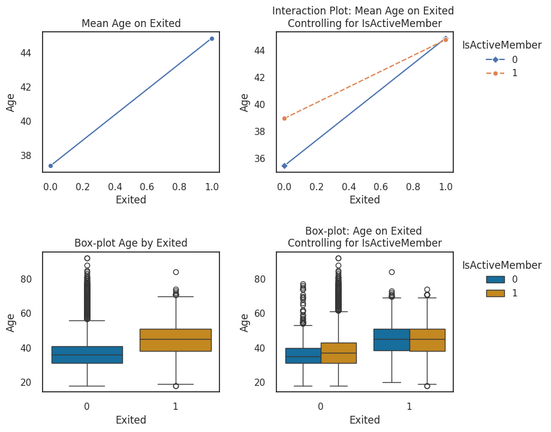

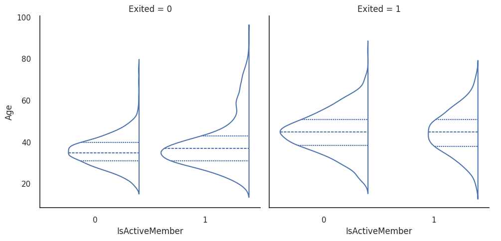

```
Mann-Whitney U Statistic between Age and IsActiveMember: 11914173.000, p-value: 0.000
--------------------------------------------------

Aligned Rank Transformation Omnibus Test on for Effects of Exit and IsActiveMember on Age:

                                          sum_sq   df      F  PR(>F)
Main effect: Exited                4218716618.88 1.00 568.87    0.00
Main effect: IsActiveMember          13257084.85 1.00   1.59    0.21
Interaction: Exited:IsActiveMember  193203740.46 1.00  23.29    0.00
--------------------------------------------------

Aligned Rank Transformation Contrast Post-Hoc Test for Interaction (Exit:IsActiveMember):

     0:0  0:1  1:0  1:1
0:0 1.00 0.00 0.00 0.00
0:1 0.00 1.00 0.00 0.00
1:0 0.00 0.00 1.00 0.65
1:1 0.00 0.00 0.65 1.00
```

```
Conditional independence between age and active status on exited statistic:  911.889, p-value: 0.000


 --------------------------------------------------

Homogeneity Test between age and active status on exited statistic:  340.270, p-value: 0.000
```

## Product Engagement and Age on Churn

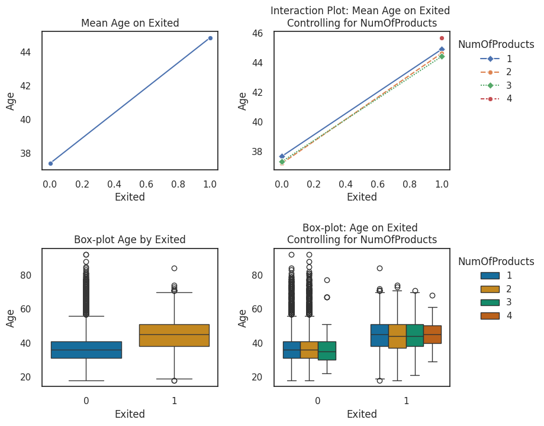

```
Kruskal H-Statistic between Age and Number of Products: 189.777,     p-value: 0.000

Dunn's test pairwise interaction comparisons for Age grouped by Number of Products:
     1    2    3    4
1 1.00 0.00 0.00 0.00
2 0.00 1.00 0.00 0.00
3 0.00 0.00 1.00 0.25
4 0.00 0.00 0.25 1.00
--------------------------------------------------

Aligned Rank Transformation Omnibus Test on for Effects of Exit and Number of Products on Age:

                                         sum_sq   df      F  PR(>F)
Main effect: Exited               5736627826.87 1.00 768.74    0.00
Main effect: NumOfProducts        1048307984.03 3.00  43.00    0.00
Interaction: Exited:NumOfProducts  175801943.35 3.00   7.12    0.00
--------------------------------------------------

Aligned Rank Transformation Contrast Post-Hoc Test for Interaction (Exit:NumOfProducts):

     0:1  0:2  0:3  1:1  1:2  1:3  1:4
0:1 1.00 0.78 1.00 0.00 0.00 0.00 0.00
0:2 0.78 1.00 1.00 0.00 0.00 0.00 0.00
0:3 1.00 1.00 1.00 0.00 0.00 0.00 0.00
1:1 0.00 0.00 0.00 1.00 1.00 1.00 1.00
1:2 0.00 0.00 0.00 1.00 1.00 1.00 1.00
1:3 0.00 0.00 0.00 1.00 1.00 1.00 1.00
1:4 0.00 0.00 0.00 1.00 1.00 1.00 1.00
```

## Data Anomalies

### Satisfaction Scores Well Distributed Among Complaining Customers

The bulk of customer churn originated from the population of customers who lodged a complaint. Analysis of complaint resolution satisfaction scores shows no significant difference between complaining and non-complaining groups. Expected concentration of low scores (1-3) among complainants was not observed. The *complaint satisfaction scoring system is ineffective* at providing actionable insight into churn propensity. It requires review and redesign to establish a reliable metric for identifying high-risk customers.

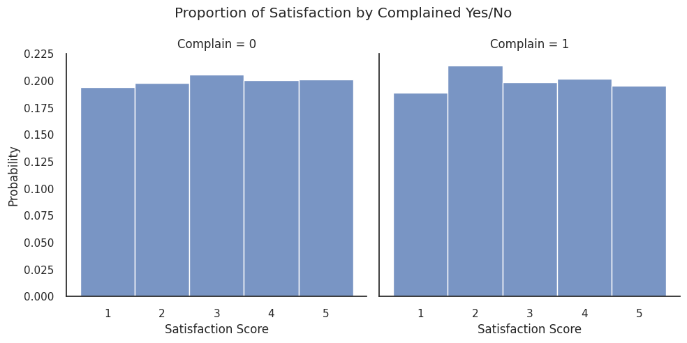

```
Chi-Square Statistic: 3.011, p-value: 0.556
```

### Credit Card Points Earned for Non-Credit Card Owners

The "*Points Earned*" variable is misleading. Despite documentation linking points exclusively to credit card usage, all customers—including non-cardholders—have points, and the point spread is statistically identical across all key customer segments (card ownership, card type, tenure, active status). One must immediately verify the data source and correct the variable definition, as the current data does not reflect expected disparities based on loyalty or premium card usage, making it useless for segmentation of churn.

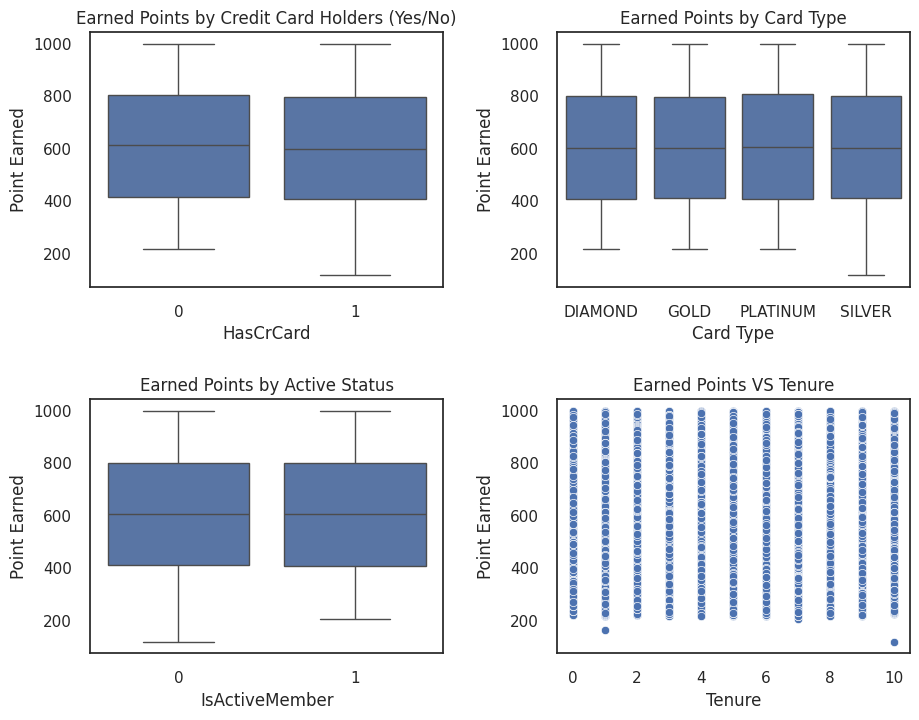

## Multivariate Analysis Conclusion

We are optimizing the churn prediction model by introducing three new interaction variables:

1. Products $\times$ Zero Balance
2. Active Member $\times$ Age
3. Products $\times$ Age

To maintain focus and efficiency, we are dropping six non-predictive variables (Credit Score, Estimated Salary, Tenure, Has Credit Card, Points Earned, and Satisfaction Score) from the prediction model. While these variables don't predict churn, they are valuable for future effect analysis on prevention strategies.

# 3 Data Preprocessing and Cleaning

Our next critical step is to consolidate and prepare the final dataset before building our predictive model. We will follow a standard, multi-stage pipeline to ensure the resulting model is both highly accurate and robust across all customer types.

We will begin by splitting our data into training and testing sets. Due to the strategic importance of customer feedback, we are taking an extra step to stratify this split, ensuring both our training and final testing environments contain a representative sample of all key customer segments: those who complain and those who churn. This prevents bias and ensures a reliable final test. We will use cross-validation (multiple tests) instead of a single validation set to further guarantee the model's consistent performance.

Based on our analysis, we are using seven key variables (Age, Geography, Gender, Active Member status, Complaint status, Zero Balance status, and Number of Products) to predict customer churn (Exited).

**The Data Preparation Pipeline:**

We will execute a three-phase preparation process:

1. Standardization and Outlier Cleanup:  
   We will clean up extreme outliers and ensure all numerical data is on the same scale, which is essential for the model to fairly weigh the impact of each factor (e.g., Age versus Number of Products).
2. Risk Balancing & New Insight Creation:
   - To combat the issue of our model only seeing a small percentage of customers who actually churn, we are using an advanced technique (SMOTENC) to rebalance the dataset. This ensures the model is highly effective at identifying the small but critical population of high-risk customers.
   - We will create new high-impact interaction terms (e.g., the combined risk of 'Number of Products' and 'Zero Balance') that proved powerful in our initial analysis.
3. Final Modeling Feed:  
   We will complete the data encoding and feed the highly prepared, balanced dataset into the classification algorithm to begin model building in the next section.

These steps ensure we deliver a model that provides actionable, reliable predictions for the business.

Specific Pipeline Steps:

1. Winsorize
2. Transform
3. Scale
4. SMOTENC
5. One-hot-encoding
6. Create interaction terms
7. Classifier

Let's take a look at what are correlation structure looks like now with our training set before and after SMOTENC

```
-----------Standard correlation plot of transformed data-------------
X_Shape: (8000, 17)
y_Shape: (8000, 1)
```

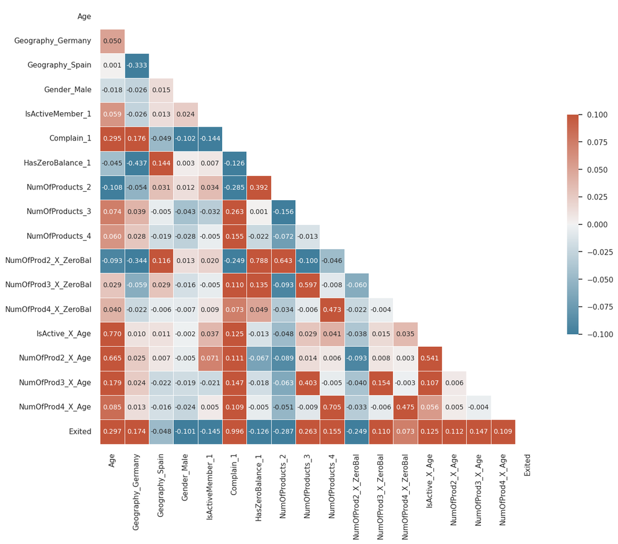

```
-----------Smotenc correlation plot of transformed data-------------
X_Shape: (12740, 17)
y_Shape: (12740, 1)
```

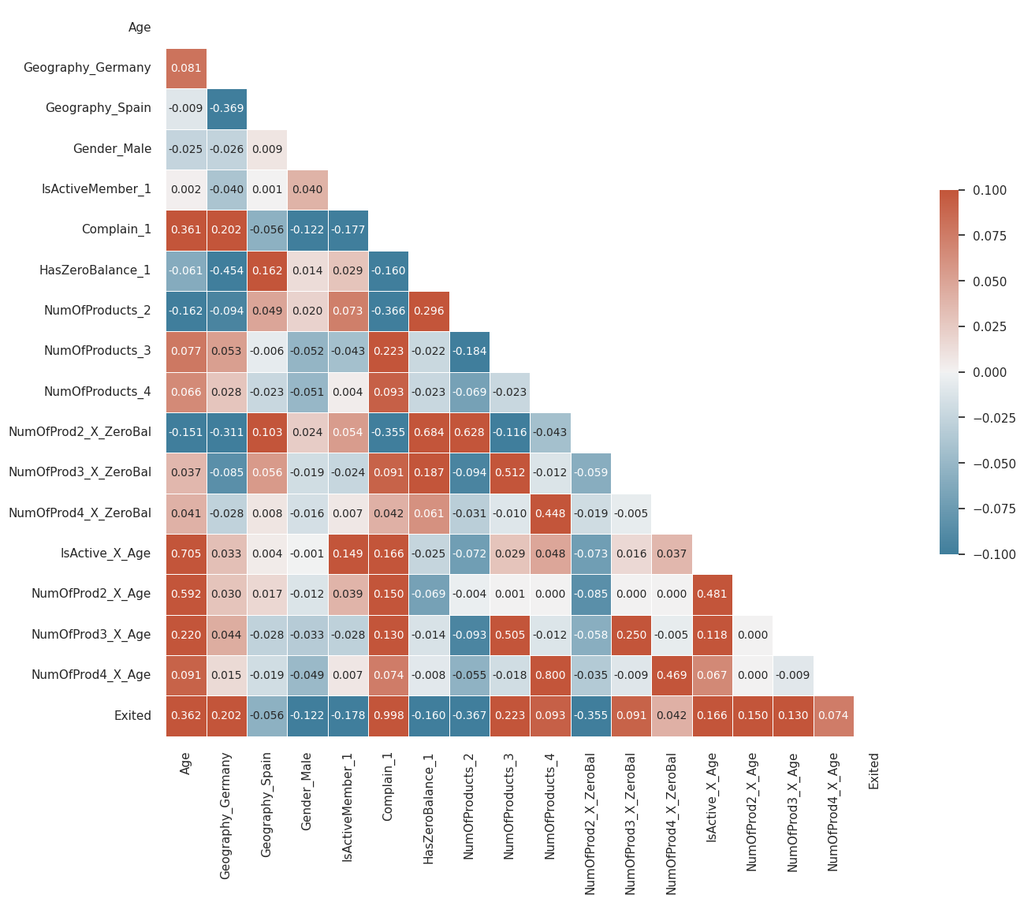

# 4 Model Implementation

We conducted a comprehensive review of several advanced modeling techniques—including complex methods like Random Forest and XG Boost—to develop the most reliable and efficient predictor of customer churn.

**Core Findings & Model Selection**

1. Exceptional Performance: After rigorous testing and tuning, all five candidate models delivered similar, excellent performance, achieving a high prediction accuracy of 99% on new, unseen customer data.
2. Simplicity Wins: Given the near-identical high performance across the board, we selected the simplest, most streamlined model: Logistic Regression. This choice minimizes implementation cost, maximizes speed, and makes the model easy to explain and maintain without sacrificing predictive power.
3. The Key Driver: Our core finding is that the final model relies almost exclusively on one critical variable: whether or not a customer registers a formal complaint.

**Strategic Gaps and Future Focus**  
While 99% accuracy is an outstanding statistical result, focusing on the single "Complain" variable reveals two important strategic gaps that we are currently addressing:

- Silent Churners (Missed Opportunities): The current model cannot effectively predict customers who leave without ever complaining (customers who "ghost" us). These represent silent attrition that we need new signals to catch.
- False Alarms (Wasted Resources): The model also struggles with customers who complain but ultimately decide to stay. If we focus intervention on every complaint, we risk over-allocating resources to customers who were never truly at risk of leaving.

In short: our model successfully confirmed that a complaint is a very strong signal for impending churn, but it doesn't solve the problem of unannounced churn.  
**Strategic Value and Next Steps**  
The model successfully answers the core problem: providing a reliable predictor of customer exit behavior based on a simple, actionable signal.

Our deep-dive analysis also revealed valuable strategic insights for the business:

- Data Quality: We identified potential holes in our data collection that, if addressed, could unlock even stronger predictive drivers.
- Product Strategy: The analysis hints at underlying issues related to product tiering or pricing structures that may be driving the complaint/churn cycle.  
  Our next future action is to build an alternative predictive model that deliberately omits the "Complain" variable to uncover these other, less obvious drivers of churn and provide a more diverse set of early warning signals.

```
Model: LogisticRegression
Best Score: 0.99862500
Best Parameters: {'classifier__C': 0.0004, 'classifier__max_iter': 50, 'classifier__penalty': 'l1', 'classifier__solver': 'liblinear'}
------------------------------
Model: SVC
Best Score: 0.99862500
Best Parameters: {'classifier__C': 0.1, 'classifier__max_iter': 100}
------------------------------
Model: RandomForest
Best Score: 0.99862500
Best Parameters: {'classifier__max_depth': None, 'classifier__max_features': 'sqrt', 'classifier__min_samples_split': 4, 'classifier__n_estimators': 100}
------------------------------
Model: AdaBoost
Best Score: 0.99862500
Best Parameters: {'classifier__learning_rate': 0.03, 'classifier__n_estimators': 50}
------------------------------
Model: XGBoost
Best Score: 0.99862500
Best Parameters: {'classifier__alpha': 50, 'classifier__colsample_bytree': 0.3, 'classifier__lambda': 50, 'classifier__learning_rate': 0.03, 'classifier__max_depth': 2, 'classifier__min_child_weight': 5, 'classifier__n_estimators': 50, 'classifier__subsample': 1.0}
------------------------------
```

```
Best model is LogisticRegression with Test Accuracy: 0.9985
Average CV metrics summary:
```

|  | model | Accuracy | Precision | Recall | F1 | F1_std |
| --- | --- | --- | --- | --- | --- | --- |
| 0 | LogisticRegression | 0.9986 | 0.9951 | 0.9982 | 0.9966 | 0.0018 |
| 1 | SVC | 0.9986 | 0.9951 | 0.9982 | 0.9966 | 0.0018 |
| 2 | RandomForest | 0.9986 | 0.9951 | 0.9982 | 0.9966 | 0.0018 |
| 3 | AdaBoost | 0.9986 | 0.9951 | 0.9982 | 0.9966 | 0.0018 |
| 4 | XGBoost | 0.9986 | 0.9951 | 0.9982 | 0.9966 | 0.0018 |

```
The final estimator in the pipeline does not have 'feature_importances_'.

Feature Coeficients:
```

|  | feature | importance |
| --- | --- | --- |
| 5 | Complain_1 | 0.4330 |
| 0 | Age | 0.0000 |
| 10 | NumOfProd2_X_ZeroBal | 0.0000 |
| 16 | NumOfProd4_X_Age | 0.0000 |
| 15 | NumOfProd3_X_Age | 0.0000 |
| 14 | NumOfProd2_X_Age | 0.0000 |
| 13 | IsActive_X_Age | 0.0000 |
| 12 | NumOfProd4_X_ZeroBal | 0.0000 |
| 11 | NumOfProd3_X_ZeroBal | 0.0000 |
| 9 | NumOfProducts_4 | 0.0000 |
| 1 | Geography_Germany | 0.0000 |
| 8 | NumOfProducts_3 | 0.0000 |
| 7 | NumOfProducts_2 | 0.0000 |
| 6 | HasZeroBalance_1 | 0.0000 |
| 4 | IsActiveMember_1 | 0.0000 |
| 3 | Gender_Male | 0.0000 |
| 2 | Geography_Spain | 0.0000 |
| 17 | intercept | 0.0000 |

```
Average CV metrics summary:
```

|  | accuracy_mean | accuracy_std | precision_mean | precision_std | recall_mean | recall_std | f1_mean | f1_std |
| --- | --- | --- | --- | --- | --- | --- | --- | --- |
| Complain | 0.3222 | 0.0076 | 0.7879 | 0.0187 | 0.7898 | 0.0187 | 0.7888 | 0.0187 |
| CreditScore | 0.0000 | 0.0000 | 0.0000 | 0.0000 | 0.0000 | 0.0000 | 0.0000 | 0.0000 |
| Geography | 0.0000 | 0.0000 | 0.0000 | 0.0000 | 0.0000 | 0.0000 | 0.0000 | 0.0000 |
| Gender | 0.0000 | 0.0000 | 0.0000 | 0.0000 | 0.0000 | 0.0000 | 0.0000 | 0.0000 |
| Age | 0.0000 | 0.0000 | 0.0000 | 0.0000 | 0.0000 | 0.0000 | 0.0000 | 0.0000 |
| Tenure | 0.0000 | 0.0000 | 0.0000 | 0.0000 | 0.0000 | 0.0000 | 0.0000 | 0.0000 |
| Balance | 0.0000 | 0.0000 | 0.0000 | 0.0000 | 0.0000 | 0.0000 | 0.0000 | 0.0000 |
| NumOfProducts | 0.0000 | 0.0000 | 0.0000 | 0.0000 | 0.0000 | 0.0000 | 0.0000 | 0.0000 |
| HasCrCard | 0.0000 | 0.0000 | 0.0000 | 0.0000 | 0.0000 | 0.0000 | 0.0000 | 0.0000 |
| IsActiveMember | 0.0000 | 0.0000 | 0.0000 | 0.0000 | 0.0000 | 0.0000 | 0.0000 | 0.0000 |
| EstimatedSalary | 0.0000 | 0.0000 | 0.0000 | 0.0000 | 0.0000 | 0.0000 | 0.0000 | 0.0000 |
| Satisfaction Score | 0.0000 | 0.0000 | 0.0000 | 0.0000 | 0.0000 | 0.0000 | 0.0000 | 0.0000 |
| Card Type | 0.0000 | 0.0000 | 0.0000 | 0.0000 | 0.0000 | 0.0000 | 0.0000 | 0.0000 |
| Point Earned | 0.0000 | 0.0000 | 0.0000 | 0.0000 | 0.0000 | 0.0000 | 0.0000 | 0.0000 |
| HasZeroBalance | 0.0000 | 0.0000 | 0.0000 | 0.0000 | 0.0000 | 0.0000 | 0.0000 | 0.0000 |

```
LogisticRegression Classification Report on Test Set:
+--------------+-------------+----------+------------+-----------+
|              |   precision |   recall |   f1-score |   support |
|--------------+-------------+----------+------------+-----------|
| 0            |       0.999 |    0.999 |      0.999 |  1592.000 |
| 1            |       0.995 |    0.998 |      0.996 |   408.000 |
| accuracy     |       0.999 |    0.999 |      0.999 |     0.999 |
| macro avg    |       0.997 |    0.998 |      0.998 |  2000.000 |
| weighted avg |       0.999 |    0.999 |      0.999 |  2000.000 |
+--------------+-------------+----------+------------+-----------+
```

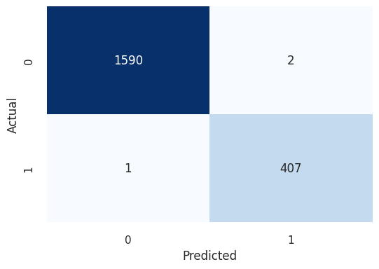

Time to save our model!

```
['bank_churn_pipeline.pkl']
```

If you would like to see my other works, you can visit:  
**[My website](https://estevanfisk.com/)**  
**[My GitHub](https://github.com/EstevanFisk)**  
**[My Kaggle](https://www.kaggle.com/bgfootball04)**  
Direct link to this file repository on my Github: **[Bank Churn Prediction](https://github.com/EstevanFisk/Bank-Customer-Churn-EDA-and-Prediction-Part-1)**.